# Apartment List Rentonomics

Christine Quan

February 20, 2017

```r
#reading in data and initial exploration
data <- read_csv("Data.csv")
summary(data)
```

```
   Location              Year        Category           Population
 Length:7362        Min.   :2006   Length:7362        Min.   :      52
 Class :character   1st Qu.:2007   Class :character   1st Qu.:   16815
 Mode  :character   Median :2009   Mode  :character   Median :   55944
                    Mean   :2009                      Mean   :  473543
                    3rd Qu.:2011                      3rd Qu.:  165562
                    Max.   :2012                      Max.   :75515104
                                                      NA's   :14
```

```r
head(data)
```

```
# A tibble: 6 × 4
       Location  Year     Category Population
          <chr> <int>        <chr>      <dbl>
1 United States  2006 Owner: 15-24     953540
2 United States  2006 Owner: 25-34    8416916
3 United States  2006 Owner: 35-44   15284446
4 United States  2006 Owner: 45-54   17955155
5 United States  2006 Owner: 55-59    8192074
6 United States  2006 Owner: 60-64    6396090
```

```r
data %>% count(Category)
```

```
# A tibble: 37 × 2
               Category     n
                  <chr> <int>
1  Owner-occupied units   217
2          Owner: 15-24   217
3          Owner: 25-34   217
4          Owner: 35-44   217
5          Owner: 45-54   217
6          Owner: 55-59   217
7          Owner: 60-64   217
8          Owner: 65-74   217
9          Owner: 75-84   217
10           Owner: 85-   217
# ... with 27 more rows
```

```r
data %>% count(Location)
```

```
# A tibble: 31 × 2
         Location     n
            <chr> <int>
1     Atlanta, GA   237
2   Baltimore, MD   237
3      Boston, MA   237
4     Chicago, IL   237
5  Cincinnati, OH   237
6   Cleveland, OH   237
7      Dallas, TX   237
8      Denver, CO   237
9     Detroit, MI   237
10    Houston, TX   237
# ... with 21 more rows
```

To make the data easier to work with later (i.e. instead of having to rewrite filters each time), I will create indicator variables and new columns to parse out the Category column. This is a relatively small data set so I am not too worried about increasing the number of columns.

*Data Quirks*

Some Cities/Category combinations have Population = NA (notably all of those have the category “Owner: Native Hawaiian and Other Pacific Islander Householder”). I am assuming these cities do not a people who identify with those ethnicities.

*Programming Note*

In terms of coding style, I will refrain from writing functions or loops so as to ensure each code chunk can be read and understood more or less independently of all the other code chunks. In addition, the plots used in this report will not be polished with title-cased axes titles as they are mostly intended for exploratory purposes. This will not be the most polished in terms of style.

```r
df <- data %>%
  mutate(own_or_rent = ifelse(str_detect(Category, "Rent"), yes = "Rent", no = "Own"),
         age_group = str_extract(Category, "\\d{2}-(\\d{2})?"),
         totals = ifelse(str_detect(Category, "units"), yes = 1, no = 0), # geographical totals
         race = str_trim(str_extract(Category,
                            "(?<=(Renter: |Owner: ))[:print:]+(?=(Household)[:alpha:]*)"))
  )
```

# 1 Growth Rate of Owner and Renter Populations

Here, I will use the Population who have renter or owner occupied units as the unit to measure growth. I define growth rate from 2006 to 2012 as the number of units in 2012 minus the number of units in 2006 taken as a percetage of the number of units in 2006.

I filtered to just the “location” of United States (which I assume provides the country-level aggregated value).

In addition to calculating the percent change since 2006, I also calculated the year over year percent change as well.

## 1.1 Owner Population - Growth Rate (2006 - 2012)

```r
own_growth <- df %>% filter(totals == 1,
                         own_or_rent == "Own",
                         Location == "United States") %>%
  arrange(Year) %>%
  mutate(yoy_percent =
           (Population - lag(Population, default = first(Population)))
         /lag(Population, default = first(Population))*100,
         percentchangefrom2006 = (Population - first(Population))/first(Population)*100)

print(own_growth %>% select(Year, Population, yoy_percent, percentchangefrom2006),
      row.names = FALSE)
```

```
# A tibble: 7 × 4
   Year Population yoy_percent percentchangefrom2006
  <int>      <dbl>       <dbl>                 <dbl>
1  2006   75086485  0.00000000             0.0000000
2  2007   75515104  0.57083375             0.5708338
3  2008   75373053 -0.18810939             0.3816506
4  2009   75320422 -0.06982734             0.3115567
5  2010   74873372 -0.59353093            -0.2838234
6  2011   74264435 -0.81328914            -1.0948042
7  2012   74119256 -0.19548927            -1.2881533
```

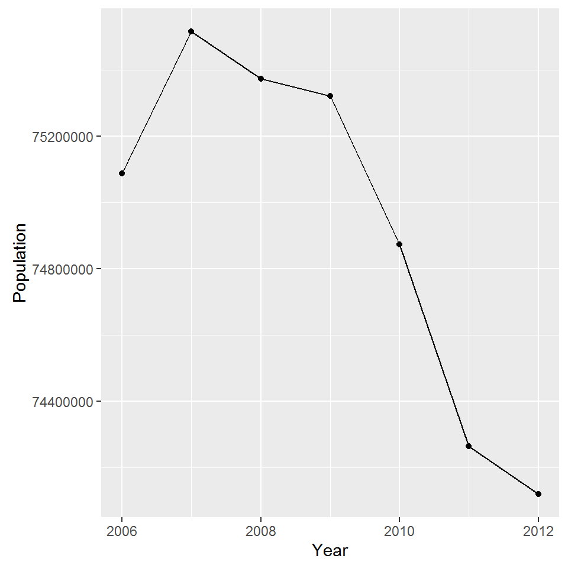

```r
own_growth %>% ggplot(mapping = aes(x = Year, y = Population)) +
  geom_point() +
  geom_line()
```

From 2006 to 2012, there was a -1.29% growth rate in owner-occupied units. So less people have owner-occupied units in 2012 than in 2006. Looking at the year-over-year growth rate reveal that apart from an increase between 2006 and 2007, there has been a steady decline of people with owner-occupied units.

## 1.2 Renter Population - Growth Rate (2006 - 2012)

```r
rent_growth <- df %>% filter(totals == 1,
                         own_or_rent == "Rent",
                         Location == "United States") %>%
  arrange(Year) %>%
  mutate(yoy_percent =
           (Population - lag(Population, default = first(Population)))
         /lag(Population, default = first(Population))*100,
         percentchangefrom2006 = (Population - first(Population))/first(Population)*100)

print(rent_growth %>% select(Year, Population, yoy_percent, percentchangefrom2006),
      row.names = FALSE)
```

```
# A tibble: 7 × 4
   Year Population yoy_percent percentchangefrom2006
  <int>      <dbl>       <dbl>                 <dbl>
1  2006   36530917   0.0000000             0.0000000
2  2007   36862873   0.9086988             0.9086988
3  2008   37728276   2.3476277             3.2776593
4  2009   37290607  -1.1600557             2.0795810
5  2010   39694047   6.4451619             8.6587753
6  2011   40727290   2.6030175            11.4871822
7  2012   41850284   2.7573502            14.5612742
```

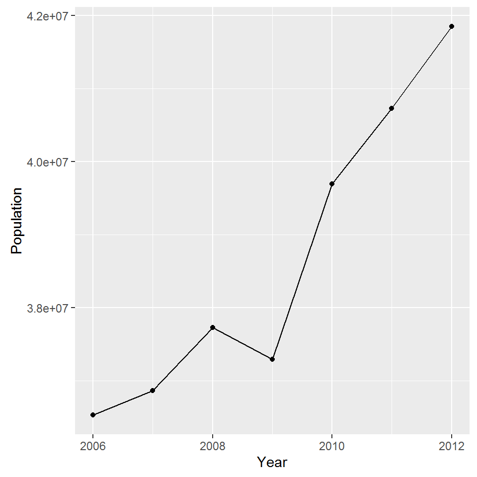

```r
rent_growth %>% ggplot(mapping = aes(x = Year, y = Population)) +
  geom_point() +
  geom_line()
```

On the other hand, there has been a 14.6% growth rate in renter-occupied units from 2006 to 2012. Looking at the year over year change reveals that aside from a decline between 2008 and 2009, there has been a general increase in renter occupied units.

That being said, there is still about double the amount of owner-occupied units than renter-occupied units.

## 1.3 Combining Renting and Ownership

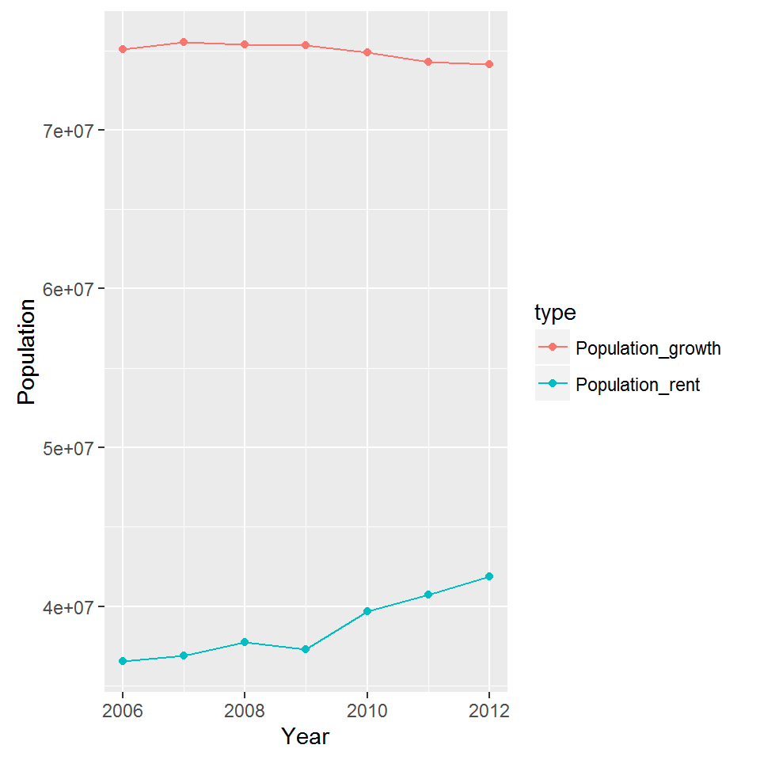

```r
all <- left_join(rent_growth, own_growth, by = c("Year"), suffix = c("_rent", "_growth")) %>%
  select(Year, Population_rent, Population_growth)

all %>%
  gather(key = type, value = Population, -Year) %>%
  ggplot(mapping = aes(x = Year, y = Population, color = type)) +
  geom_point() +
  geom_line()
```

# 2 Home Ownerships has decreased the most with…

## 2.1 All Categories

```r
allcat <- df %>% filter(!is.na(Population), #Population is NA for some races in certain locations
              own_or_rent == "Own",
              totals == 0) %>%  #filter out the aggregates
  group_by(Category, Year) %>%
  summarise(Population = sum(Population)) %>%
  group_by(Category) %>%
  arrange(Year) %>%
  mutate(yoy_percent =
           (Population - lag(Population, default = first(Population)))
         /lag(Population, default = first(Population))*100,
         percentchangefrom2006 = (Population - first(Population))/first(Population)*100)

# to get the % change in 2012 (since 2006)
print(allcat %>%
        filter(Year == 2012) %>%
        select(Category, percentchangefrom2006) %>%
        arrange(percentchangefrom2006),
      row.names = FALSE)
```

```
Source: local data frame [18 x 2]
Groups: Category [18]

                                                        Category
                                                           <chr>
1                                                   Owner: 15-24
2                             Owner: Some Other Race Householder
3                                                   Owner: 25-34
4                                                   Owner: 35-44
5                                                   Owner: 45-54
6                          Owner: Non-Hispanic White Householder
7                             Owner: African American Households
8                                                   Owner: 75-84
9            Owner: American Indian and Alaska Native Households
10 Owner: Native Hawaiian and Other Pacific Islander Householder
11                                                  Owner: 55-59
12                                   Owner: Hispanic Householder
13                                       Owner: Asian Households
14                                      Owner: Asian Householder
15                                                  Owner: 65-74
16                                                  Owner: 60-64
17                                                    Owner: 85-
18                          Owner: Two or More Races Householder
# ... with 1 more variables: percentchangefrom2006 <dbl>
```

Taking a quick look at all of the categories, it appears that age groups tend to be indicator of signifcant change in home ownership.

Let’s explore all of the catgories in detail…

## 2.2 Age

```r
age <- df %>% filter(!is.na(age_group),
              own_or_rent == "Own",
              Location == "United States") %>%
  group_by(age_group) %>%
  arrange(Year) %>%
   mutate(yoy_percent =
           (Population - lag(Population, default = first(Population)))
         /lag(Population, default = first(Population))*100,
         percentchangefrom2006 = (Population - first(Population))/first(Population)*100)

# to get the % change in 2012 (since 2006)
print(age %>%
        filter(Year == 2012) %>%
        select(age_group, percentchangefrom2006),
      row.names = FALSE)
```

```
Source: local data frame [9 x 2]
Groups: age_group [9]

  age_group percentchangefrom2006
      <chr>                 <dbl>
1     15-24            -39.159553
2     25-34            -20.112782
3     35-44            -19.879091
4     45-54             -6.105010
5     55-59              6.351896
6     60-64             27.084391
7     65-74             25.425741
8     75-84              1.287080
9       85-             26.967537
```

While age groups containing those older than 55 years old showed an increase in home ownership between between 2006 and 2012, those who belong to the age groups that are younger than 55 years old actually eperienced a decline in home ownership during this time period.

In particularly, the 15-24 age group experienced the highest decrease in home ownership between 2006 and 2012 with a drop in 39.2%

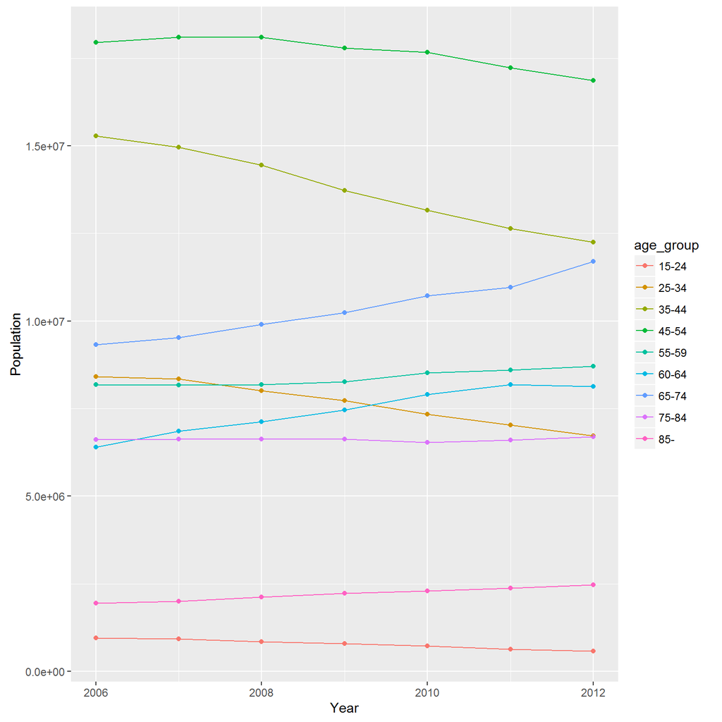

```r
age %>%
  ggplot(mapping = aes(x = Year, y = Population, color = age_group)) +
  geom_point() +
  geom_line()
```

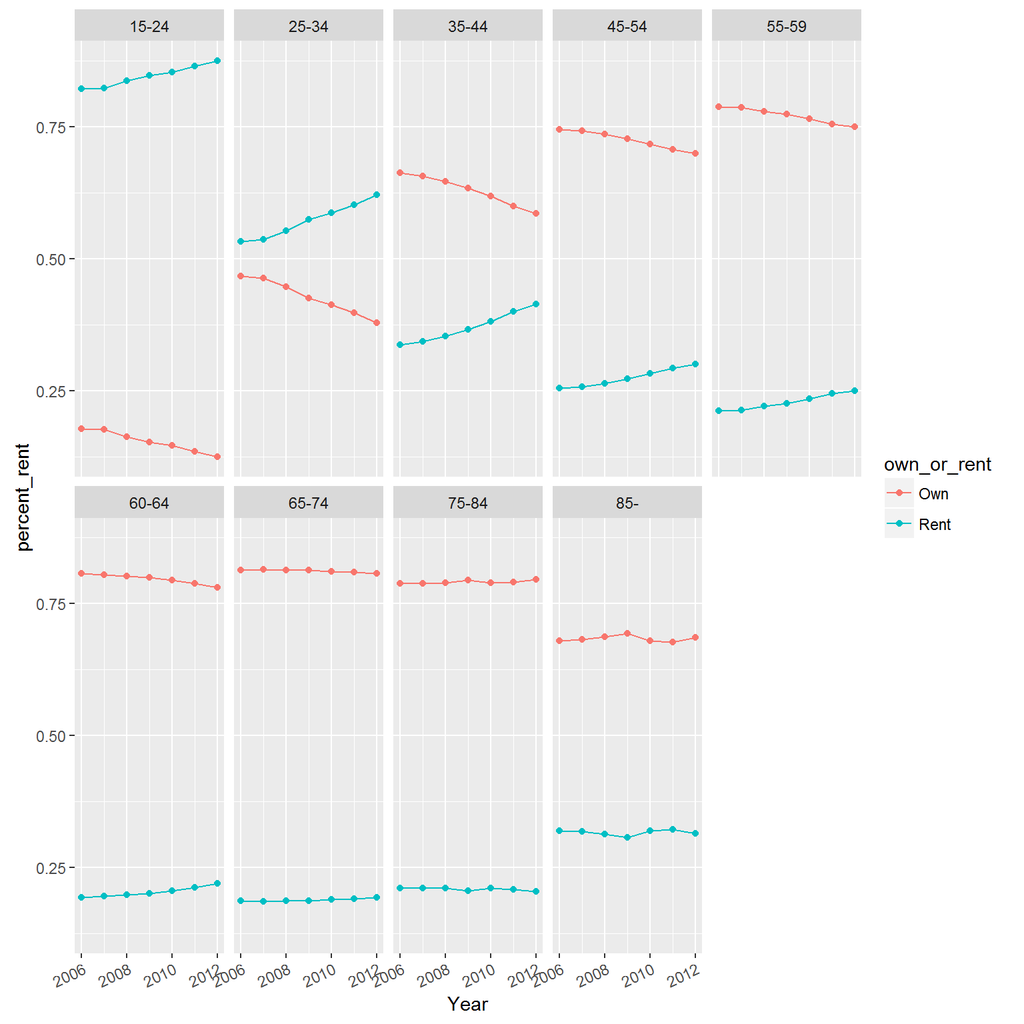

```r
# Rental Proportions
age_prop <- df %>% filter(!is.na(age_group),
              Location == "United States") %>%
  group_by(age_group, Year) %>%
  mutate(percent_rent = Population/sum(Population))

age_prop %>%
  ggplot(mapping = aes(x = Year, y = percent_rent,
                       color = own_or_rent)) +
  geom_point() +
  geom_line() +
  facet_wrap(~age_group, nrow = 2) +
   theme(axis.text.x = element_text(angle = 25, hjust = 1))
```

While this chart might be a little dense, it does illuminate the fact a few interesting ideas:

1. the two youngset age groups (15-24) and (25-34) have a higher proportion of renters and buyers.For these two groups, the lines are also diverging, showing that over time, there seems to be an increase of the population with rental units.
2. In the second row, particularly for the 65+ age group, there appears to be a stable renting/buying habit as the proportions have not changed at all over time for these age groups.
3. For the middle age groups (especially with the 35-44 age group), there appears to be a trend of decreasing ownership and increasing rentalship. It is possible that after 2012, the proportion of renters could exceed the proprtion of buyers for these age groups.

## 2.3 Ethnicty

```r
race <- df %>% filter(!is.na(race),
              own_or_rent == "Own",
              Location == "United States") %>%
  group_by(race) %>%
  arrange(Year) %>%
   mutate(yoy_percent =
           (Population - lag(Population, default = first(Population)))
         /lag(Population, default = first(Population))*100,
         percentchangefrom2006 = (Population - first(Population))/first(Population)*100)

# to get the % change in 2012 (since 2006)
print(race %>%
        filter(Year == 2012) %>%
        select(race, percentchangefrom2006) %>%
        arrange(percentchangefrom2006),
      row.names = FALSE)
```

```
Source: local data frame [8 x 2]
Groups: race [8]

                                        race percentchangefrom2006
                                       <chr>                 <dbl>
1                            Some Other Race           -38.6564667
2                         Non-Hispanic White            -2.9053496
3                           African American            -1.3107927
4          American Indian and Alaska Native             0.6402228
5 Native Hawaiian and Other Pacific Islander             4.9870158
6                                   Hispanic             7.8057714
7                                      Asian            10.5286327
8                          Two or More Races            27.4759843
```

Those who identified as “Some Other Race,” “Non Hispanic White,” or “African American” showed a decrease in home ownernship between 2006 and 2012.

Overall, if we divide the population by race, there is very little change overall. Asians and Hispanics showed above 5% increase in home ownership.

However, the most interesting changes are those that are less racially identifiable (i.e. those who identified as “Two or More Races” or “Some Other Race”). Those who identify as “Two or More Races” showed the highest increase in home ownership while those who identify as “Some Other Race” showed the greatest decrease (38.7%) in terms of home ownership.

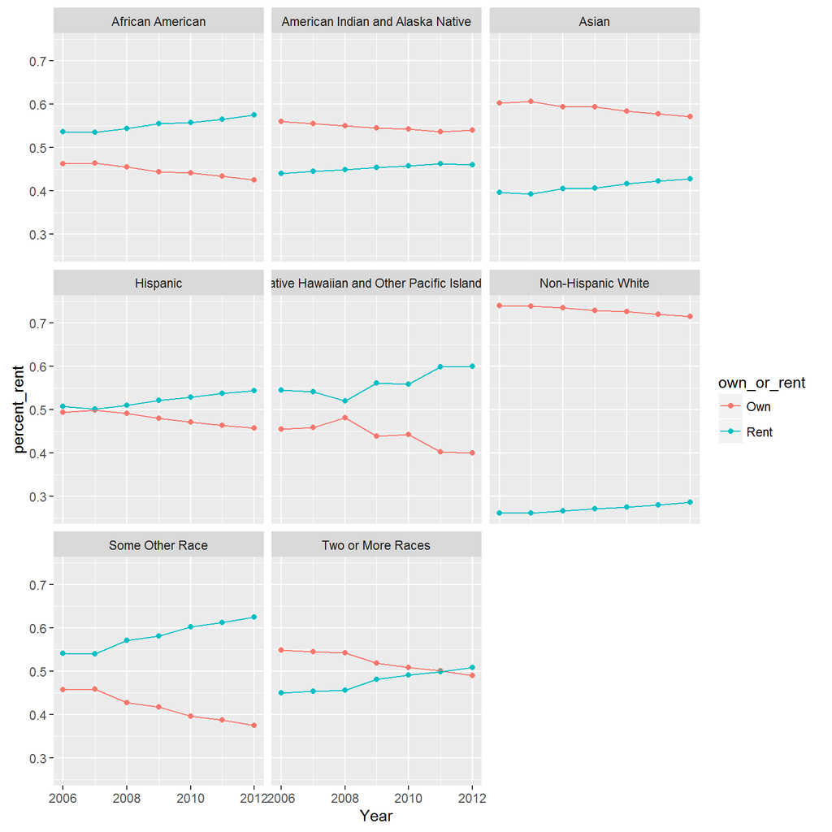

```r
# Rental Proportions
age_prop <- df %>% filter(!is.na(race),
              Location == "United States") %>%
  group_by(race, Year) %>%
  mutate(percent_rent = Population/sum(Population))

age_prop %>%
  ggplot(mapping = aes(x = Year, y = percent_rent,
                       color = own_or_rent)) +
  geom_point() +
  geom_line() +
  facet_wrap(~race)
```

Again, it is interesting to note the longitudinally diverging or converging lines of rentalship or ownership proprtions.

## 2.4 Location

There are thirty different cities in this data set.

```r
cities <- df %>% filter(!is.na(Population), #Population is NA for some races in certain locations
              own_or_rent == "Own",
              totals  == 1, # to just get the city- evel aggregates
              Location != "United States" ) %>% #filter out the aggregate data and just get cities
  group_by(Location) %>%
  arrange(Year) %>%
   mutate(yoy_percent =
           (Population - lag(Population, default = first(Population)))
         /lag(Population, default = first(Population))*100,
         percentchangefrom2006 = (Population - first(Population))/first(Population)*100)

# to get the % change in 2012 (since 2006)
print(cities %>%
        filter(Year == 2012) %>%
        select(Location, percentchangefrom2006) %>%
        arrange(percentchangefrom2006),
      row.names = FALSE)
```

```
Source: local data frame [30 x 2]
Groups: Location [30]

          Location percentchangefrom2006
             <chr>                 <dbl>
1      Detroit, MI             -9.893925
2        Miami, FL             -7.510244
3        Tampa, FL             -7.120967
4    Las Vegas, NV             -6.662166
5    Cleveland, OH             -6.596722
6  Los Angeles, CA             -5.675692
7      Chicago, IL             -4.594099
8      Orlando, FL             -4.334914
9    San Diego, CA             -4.290754
10   Riverside, CA             -4.279835
# ... with 20 more rows
```

Grouping by cities don’t reveal as large of changes as age. All of the changes were less than 10%. Detroit did show the largest decrease in home ownership at 9.89%. The Texan cities showed the most increase in home ownership.

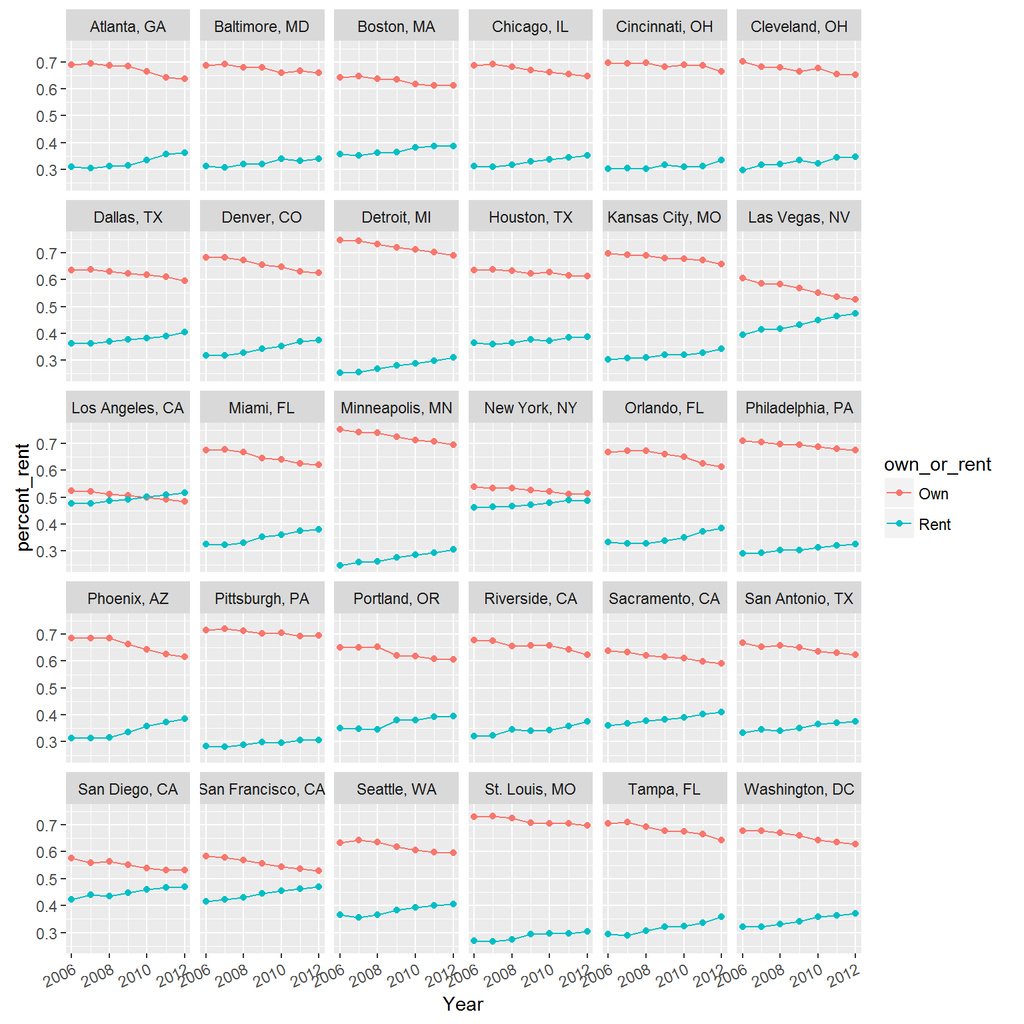

```r
# Rental Proportions
loc_prop <- df %>% filter(!is.na(Population),
                          totals == 1,
              Location != "United States") %>%
  group_by(Location, Year) %>%
  mutate(percent_rent = Population/sum(Population))

loc_prop %>%
  ggplot(mapping = aes(x = Year, y = percent_rent,
                       color = own_or_rent)) +
  geom_point() +
  geom_line() +
  facet_wrap(~Location) +
  theme(axis.text.x = element_text(angle = 25, hjust = 1))
```

In no city but Los Angeles (for the time period between 2006 and 2012) has the number of renters exceeded the number of homebuyers. However, all cities seem to be show an increasing proportion of renters. In 2012, Las Vegas, New York, and San Francisco all seem on the brink of having more renters than buyers.

# 3 Where are renters moving to?

I am interpreting this question as: what cities have seen the highest growth of renters between 2006 and 2012?

With that question in mind, the analysis is similar to what I did in the previous section. The conclusions will be limited since we only have thirty cities in this dataset.

```r
cities <- df %>% filter(!is.na(Population), #Population is NA for some races in certain locations
              own_or_rent == "Rent",
              totals  == 1, # to just get the city- evel aggregates
              Location != "United States" ) %>% #filter out the aggregate data and just get cities
  group_by(Location) %>%
  arrange(Year) %>%
   mutate(yoy_percent =
           (Population - lag(Population, default = first(Population)))
         /lag(Population, default = first(Population))*100,
         percentchangefrom2006 = (Population - first(Population))/first(Population)*100)

# to get the % change in 2012 (since 2006)
print(cities %>%
        filter(Year == 2012) %>%
        select(Location, percentchangefrom2006) %>%
        arrange(desc(percentchangefrom2006)),
      row.names = FALSE)
```

```
Source: local data frame [30 x 2]
Groups: Location [30]

          Location percentchangefrom2006
             <chr>                 <dbl>
1      Phoenix, AZ              33.16972
2  San Antonio, TX              30.84529
3  Minneapolis, MN              29.86652
4    Las Vegas, NV              29.39230
5       Denver, CO              28.04002
6       Dallas, TX              24.64989
7   Washington, DC              24.07888
8        Tampa, FL              23.60709
9      Atlanta, GA              23.07461
10   Riverside, CA              21.60102
# ... with 20 more rows
```

The top three cities that have seen the hightest growth of renters between 2006 and 2012 are:

1. Phoenix, AZ
2. San Antonio, TX
3. Minneapolis, MN

## 3.1 Renter Movement by All Categories

```r
cities <- df %>% filter(!is.na(Population), #Population is NA for some races in certain locations
              own_or_rent == "Rent",
              totals  == 0, # to just get the city- evel aggregates
              Location != "United States" ) %>% #filter out the aggregate data and just get cities
  group_by(Location, Category, Year) %>%
  summarise(Population = sum(Population)) %>%
  group_by(Location, Category) %>%
  arrange(Year) %>%
  mutate(yoy_percent =
           (Population - lag(Population, default = first(Population)))
         /lag(Population, default = first(Population))*100,
         percentchangefrom2006 = (Population - first(Population))/first(Population)*100)

# to get the % change in 2012 (since 2006)
print(cities %>%
        filter(Year == 2012) %>%
        select(Location, Category, percentchangefrom2006) %>%
        arrange(desc(percentchangefrom2006)),
      row.names = FALSE)
```

```
Source: local data frame [480 x 3]
Groups: Location, Category [480]

           Location                                             Category
              <chr>                                                <chr>
1  Philadelphia, PA                Renter: Two or More Races Householder
2    Cincinnati, OH Renter: American Indian and Alaska Native Households
3       Atlanta, GA Renter: American Indian and Alaska Native Households
4       Chicago, IL Renter: American Indian and Alaska Native Households
5     Riverside, CA                                        Renter: 60-64
6     Las Vegas, NV                Renter: Two or More Races Householder
7     Baltimore, MD Renter: American Indian and Alaska Native Households
8       Atlanta, GA                Renter: Two or More Races Householder
9       Phoenix, AZ                                        Renter: 60-64
10      Houston, TX                Renter: Two or More Races Householder
# ... with 470 more rows, and 1 more variables:
#   percentchangefrom2006 <dbl>
```

## 3.2 Renter Movement by Age Group

I am interpreting this question as when faceting by age group and location, which combinations of age group and location show the higest renter growth from 2006 to 2012.

```r
cities_age <- df %>% filter(!is.na(Population), #Population is NA for some races in certain locations
              own_or_rent == "Rent",
              totals  == 0, # to just get the city- evel aggregates
              !is.na(age_group), # just to look at age groups
              Location != "United States" ) %>% #filter out the aggregate data and just get cities
  group_by(age_group, Location, Year) %>%
  summarise(Population = sum(Population)) %>%
  group_by(age_group, Location) %>%
  arrange(Year) %>%
  mutate(yoy_percent =
           (Population - lag(Population, default = first(Population)))
         /lag(Population, default = first(Population))*100,
         percentchangefrom2006 = (Population - first(Population))/first(Population)*100)

# to get the % change in 2012 (since 2006)
print(cities_age %>%
        filter(Year == 2012) %>%
        select(age_group, Location, percentchangefrom2006) %>%
        arrange(desc(percentchangefrom2006)),
      row.names = FALSE)
```

```
Source: local data frame [270 x 3]
Groups: age_group, Location [270]

   age_group        Location percentchangefrom2006
       <chr>           <chr>                 <dbl>
1      60-64   Riverside, CA             104.92189
2      60-64     Phoenix, AZ              98.49517
3      60-64 Minneapolis, MN              87.02674
4      60-64  Cincinnati, OH              83.23784
5      60-64  Sacramento, CA              81.26646
6      65-74     Phoenix, AZ              80.57467
7      60-64      Denver, CO              80.29813
8      60-64   St. Louis, MO              78.15249
9      60-64   San Diego, CA              77.78039
10     60-64     Atlanta, GA              74.95454
# ... with 260 more rows
```

The 60-64 age group appear to have the highest growth by city. The top five cities that this renter age group is moving into are:

1. Riverside, CA
2. Phoenix, AZ
3. Minneapolis, MN
4. Cincinatti, OH
5. Sacramento, CA

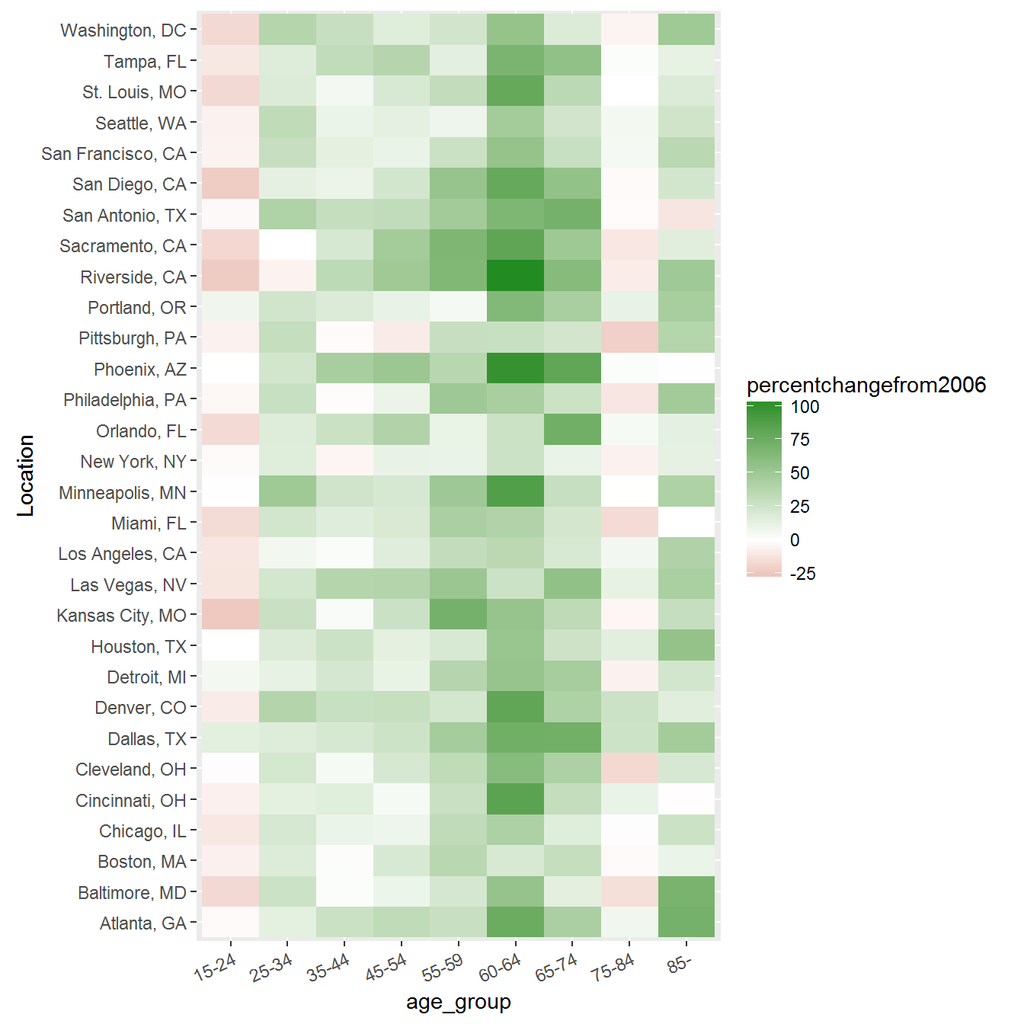

```r
cities_age %>%
  ggplot(mapping = aes(x = age_group, y = Location)) +
  geom_tile(aes(fill = percentchangefrom2006)) +
  scale_fill_gradient2(low = "darkred", mid = "white", high = "forestgreen",
                       midpoint =  0) +
  theme(axis.text.x = element_text(angle = 25, hjust = 1))
```

## 3.3 Renter Movement by Ethnicity

I am interpreting this question as when faceting by enthnicity and location, which combinations of age group and location show the higest renter growth from 2006 to 2012.

```r
cities_eth <- df %>% filter(!is.na(Population), #Population is NA for some races in certain locations
              own_or_rent == "Rent",
              totals  == 0, # to just get the city- evel aggregates
              !is.na(race), # just to look at age groups
              Location != "United States" ) %>% #filter out the aggregate data and just get cities
  group_by(race, Location, Year) %>%
  summarise(Population = sum(Population)) %>%
  group_by(race, Location) %>%
  arrange(Year) %>%
  mutate(yoy_percent =
           (Population - lag(Population, default = first(Population)))
         /lag(Population, default = first(Population))*100,
         percentchangefrom2006 = (Population - first(Population))/first(Population)*100)

# to get the % change in 2012 (since 2006)
print(cities_eth %>%
        filter(Year == 2012) %>%
        select(race, Location, percentchangefrom2006) %>%
        arrange(desc(percentchangefrom2006)),
      row.names = FALSE)
```

```
Source: local data frame [210 x 3]
Groups: race, Location [210]

                                race         Location
                               <chr>            <chr>
1                  Two or More Races Philadelphia, PA
2  American Indian and Alaska Native   Cincinnati, OH
3  American Indian and Alaska Native      Atlanta, GA
4  American Indian and Alaska Native      Chicago, IL
5                  Two or More Races    Las Vegas, NV
6  American Indian and Alaska Native    Baltimore, MD
7                  Two or More Races      Atlanta, GA
8                  Two or More Races      Houston, TX
9                  Two or More Races       Dallas, TX
10                 Two or More Races    San Diego, CA
# ... with 200 more rows, and 1 more variables:
#   percentchangefrom2006 <dbl>
```

Those who identified as “Two or More Races” or “American Indian and Alaska Native” appear to be moving the most into these 30 cities.

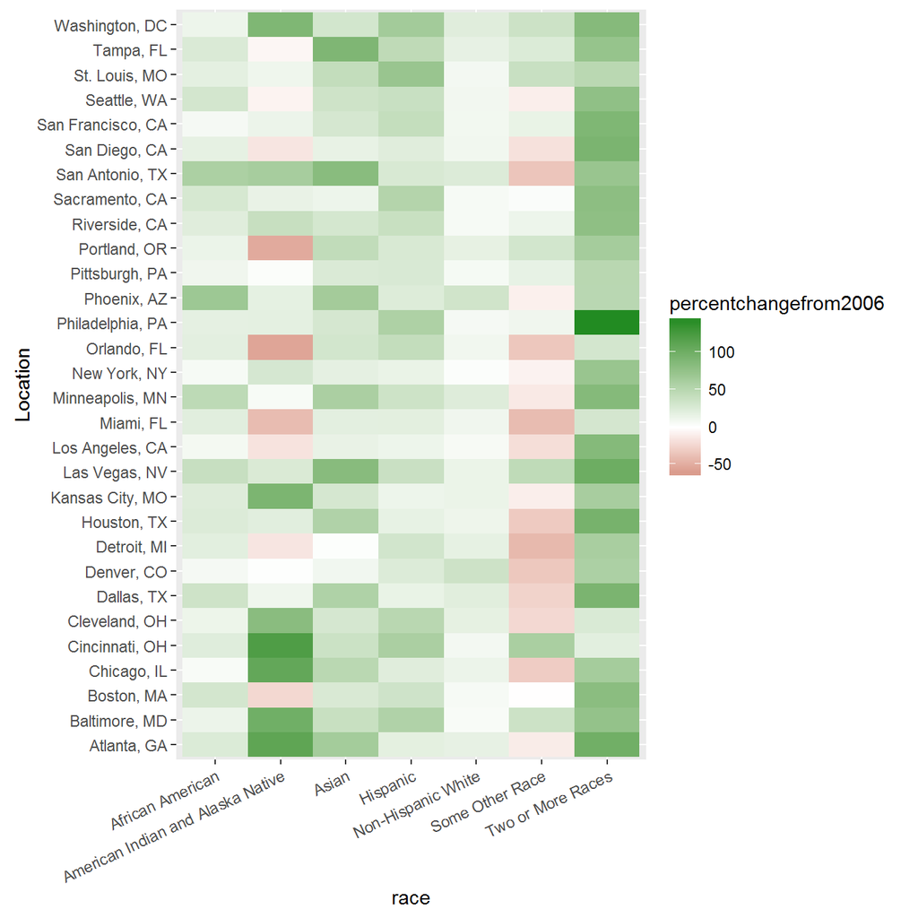

```r
cities_eth %>%
  ggplot(mapping = aes(x = race, y = Location)) +
  geom_tile(aes(fill = percentchangefrom2006)) +
  scale_fill_gradient2(low = "darkred", mid = "white", high = "forestgreen",
                       midpoint =  0) +
  theme(axis.text.x = element_text(angle = 25, hjust = 1))
```

Those who identified as “Some Other Race” do not appear to be moving into these particular cities in 2012 compared to 2006.

# 4 Four Cities - Population and Housing Trends

## 4.1 Dallas

```r
cities_age <- df %>% filter(!is.na(Population),
              own_or_rent == "Rent",
              totals  == 0, # to just get the city- evel aggregates
              age_group == "15-24", # just to look at age groups
              Location != "United States" ) %>% #filter out the aggregate data and just get cities
  group_by(age_group, Location, Year) %>%
  summarise(Population = sum(Population)) %>%
  group_by(age_group, Location) %>%
  arrange(Year) %>%
  mutate(yoy_percent =
           (Population - lag(Population, default = first(Population)))
         /lag(Population, default = first(Population))*100,
         percentchangefrom2006 = (Population - first(Population))/first(Population)*100)

# to get the % change in 2012 (since 2006)
print(cities_age %>%
        filter(Year == 2012) %>%
        select(age_group, Location, percentchangefrom2006) %>%
        arrange(desc(percentchangefrom2006)),
      row.names = FALSE)
```

```
Source: local data frame [30 x 3]
Groups: age_group, Location [30]

   age_group        Location percentchangefrom2006
       <chr>           <chr>                 <dbl>
1      15-24      Dallas, TX            14.6071002
2      15-24    Portland, OR             7.8395781
3      15-24     Detroit, MI             6.1821171
4      15-24 Minneapolis, MN             0.8200425
5      15-24     Houston, TX             0.2071055
6      15-24     Phoenix, AZ            -0.1406946
7      15-24   Cleveland, OH            -1.1108451
8      15-24     Atlanta, GA            -1.9664462
9      15-24    New York, NY            -2.3091514
10     15-24 San Antonio, TX            -2.6151726
# ... with 20 more rows
```

```r
cities <- df %>% filter(!is.na(Population), #Population is NA for some races in certain locations
              own_or_rent == "Own",
              totals  == 1, # to just get the city- evel aggregates
              Location != "United States" ) %>% #filter out the aggregate data and just get cities
  group_by(Location) %>%
  arrange(Year) %>%
   mutate(yoy_percent =
           (Population - lag(Population, default = first(Population)))
         /lag(Population, default = first(Population))*100,
         percentchangefrom2006 = (Population - first(Population))/first(Population)*100)

# to get the % change in 2012 (since 2006)
print(cities %>%
        filter(Year == 2012) %>%
        select(Location, percentchangefrom2006) %>%
        arrange(desc(percentchangefrom2006)),
      row.names = FALSE)
```

```
Source: local data frame [30 x 2]
Groups: Location [30]

          Location percentchangefrom2006
             <chr>                 <dbl>
1      Houston, TX            8.92308941
2  San Antonio, TX            8.11249153
3       Dallas, TX            4.84283648
4      Seattle, WA           -0.09238952
5       Boston, MA           -0.53843369
6   Washington, DC           -0.55113739
7     Portland, OR           -0.83242750
8    Baltimore, MD           -1.15020347
9       Denver, CO           -1.37358131
10  Cincinnati, OH           -1.71711433
# ... with 20 more rows
```

The number of renters may be increasing, but the number of homebuyers are as well. Texan cities (Houston, San Antonio, and Dallas) showed the strongest increase in homeownership amongst all major cities in the United States from 2006 to 2012.

## 4.2 Los Angeles

```r
LA_age <- df %>% filter(!is.na(Population), #Population is NA for some races in certain locations
              own_or_rent == "Own",
              totals  == 0, # to just get the city- evel aggregates
              !is.na(age_group), # just to look at age groups
              Location == "Los Angeles, CA" ) %>%
  group_by(age_group, Location, Year) %>%
  summarise(Population = sum(Population)) %>%
  group_by(age_group, Location) %>%
  arrange(Year) %>%
  mutate(yoy_percent =
           (Population - lag(Population, default = first(Population)))
         /lag(Population, default = first(Population))*100,
         percentchangefrom2006 = (Population - first(Population))/first(Population)*100)

# to get the % change in 2012 (since 2006)
print(LA_age %>%
        filter(Year == 2012) %>%
        select(age_group, Location, percentchangefrom2006) %>%
        arrange(desc(percentchangefrom2006)),
      row.names = FALSE)
```

```
Source: local data frame [9 x 3]
Groups: age_group, Location [9]

  age_group        Location percentchangefrom2006
      <chr>           <chr>                 <dbl>
1       85- Los Angeles, CA             41.684743
2     65-74 Los Angeles, CA             19.624649
3     60-64 Los Angeles, CA             19.139303
4     55-59 Los Angeles, CA              1.594867
5     75-84 Los Angeles, CA             -1.488244
6     45-54 Los Angeles, CA             -9.918547
7     25-34 Los Angeles, CA            -26.611316
8     35-44 Los Angeles, CA            -27.186291
9     15-24 Los Angeles, CA            -30.144524
```

```r
LA_age <- df %>% filter(!is.na(Population), #Population is NA for some races in certain locations
              own_or_rent == "Rent",
              totals  == 0, # to just get the city- evel aggregates
              !is.na(age_group), # just to look at age groups
              Location == "Los Angeles, CA" ) %>%
  group_by(age_group, Location, Year) %>%
  summarise(Population = sum(Population)) %>%
  group_by(age_group, Location) %>%
  arrange(Year) %>%
  mutate(yoy_percent =
           (Population - lag(Population, default = first(Population)))
         /lag(Population, default = first(Population))*100,
         percentchangefrom2006 = (Population - first(Population))/first(Population)*100)

# to get the % change in 2012 (since 2006)
print(LA_age %>%
        filter(Year == 2012) %>%
        select(age_group, Location, percentchangefrom2006) %>%
        arrange(desc(percentchangefrom2006)),
      row.names = FALSE)
```

```
Source: local data frame [9 x 3]
Groups: age_group, Location [9]

  age_group        Location percentchangefrom2006
      <chr>           <chr>                 <dbl>
1       85- Los Angeles, CA             40.394991
2     60-64 Los Angeles, CA             35.117239
3     55-59 Los Angeles, CA             30.913524
4     65-74 Los Angeles, CA             20.105526
5     45-54 Los Angeles, CA             16.008117
6     25-34 Los Angeles, CA              6.840617
7     75-84 Los Angeles, CA              6.528804
8     35-44 Los Angeles, CA              3.076457
9     15-24 Los Angeles, CA            -10.823928
```

Los Angeles is a city distinguished by many things: Hollywood, Beverley Hills, boardwalks and beaches. As of 2012, LA is also the only city (in a list of thirty major cities) that has a higher percentage of renters than homebuyers.

## 4.3 Phoenix

```r
own_growth <- df %>% filter(totals == 1,
                         #own_or_rent == "Rent",
                         Location == "Phoenix, AZ") %>%
  arrange(Year) %>%
  mutate(yoy_percent =
           (Population - lag(Population, default = first(Population)))
         /lag(Population, default = first(Population))*100,
         percentchangefrom2006 = (Population - first(Population))/first(Population)*100)

print(own_growth %>% select(Year, Population, yoy_percent, percentchangefrom2006),
      row.names = FALSE)
```

```
# A tibble: 14 × 4
    Year Population yoy_percent percentchangefrom2006
   <int>      <dbl>       <dbl>                 <dbl>
1   2006     979314     0.00000             0.0000000
2   2006     447794   -54.27473           -54.2747270
3   2007     993737   121.91834             1.4727656
4   2007     456220   -54.09047           -53.4143288
5   2008    1000142   119.22362             2.1267949
6   2008     461557   -53.85085           -52.8693555
7   2009     976778   111.62673            -0.2589568
8   2009     495371   -49.28520           -49.4165303
9   2010     966014    95.00819            -1.3580935
10  2010     537093   -44.40112           -45.1562012
11  2011     957874    78.34416            -2.1892876
12  2011     572069   -40.27722           -41.5847215
13  2012     954941    66.92759            -2.4887830
14  2012     596326   -37.55363           -39.1077836
```

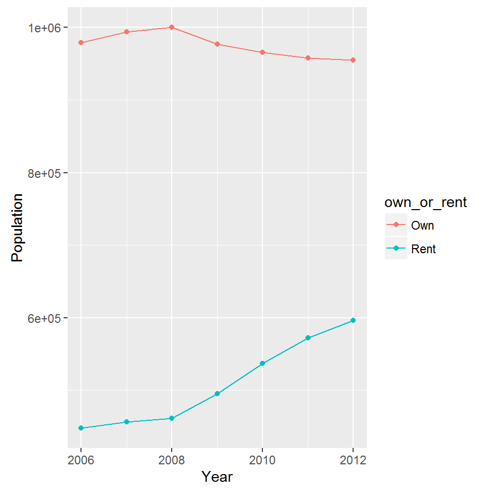

```r
own_growth %>% ggplot(mapping = aes(x = Year, y = Population, color = own_or_rent)) +
  geom_point() +
  geom_line()
```

Sunny Phoenix, Arizona saw the highest renter growth between 2006 and 2012. The Valley of the Sun, with its temperate weather famously (like the rest of Arizona) does not observe Daylight Savings Time. Blessed with abundant sunshine and warm weather, the city seems to be a great place to live. The population of 60-64 year old renters has nearly doubled between 2006 and 2012, making it the city with the second highest increase of 60-64 renter growth in the nation, just after Riverside, California.

Like most other large cities in the nation, Phoenix still has a higher number of homeowners than renters. However, the gap appears to be closing as the number of homeowners decrease over time and the number of renters increase. Renters appear to be increasing at a faster rate than homeownership is dropping.

## 4.4 Las Vegas

```r
cities_age <- df %>% filter(!is.na(Population), #Population is NA for some races in certain locations
              own_or_rent == "Own",
              totals  == 0, # to just get the city- evel aggregates
              !is.na(age_group), # just to look at age groups
              Location != "United States" ) %>% #filter out the aggregate data and just get cities
  group_by(age_group, Location, Year) %>%
  summarise(Population = sum(Population)) %>%
  group_by(age_group, Location) %>%
  arrange(Year) %>%
  mutate(yoy_percent =
           (Population - lag(Population, default = first(Population)))
         /lag(Population, default = first(Population))*100,
         percentchangefrom2006 = (Population - first(Population))/first(Population)*100)

# to get the % change in 2012 (since 2006)
print(cities_age %>%
        filter(Year == 2012) %>%
        select(age_group, Location, percentchangefrom2006) %>%
        arrange(desc(percentchangefrom2006)),
      row.names = FALSE)
```

```
Source: local data frame [270 x 3]
Groups: age_group, Location [270]

   age_group        Location percentchangefrom2006
       <chr>           <chr>                 <dbl>
1        85-   Las Vegas, NV             118.70772
2        85-     Houston, TX              60.79857
3        85-  Sacramento, CA              50.08429
4        85-      Dallas, TX              48.27985
5        85- Minneapolis, MN              47.55994
6      65-74     Atlanta, GA              46.74609
7        85-     Seattle, WA              46.27798
8      60-64  Sacramento, CA              43.83273
9        85- Kansas City, MO              42.47830
10       85-      Boston, MA              42.02016
# ... with 260 more rows
```

Las Vegas is known for its vibrant casinos and neon streets teeming with revelers. Lesser known about the city is the fact that it boasts the highest increase in homeownership amongst the 85+ age group. While this age group has seen an increase in home ownership in many cities (Houston, Dallas, Sacramento, Minneapolis), Las Vegas is the only major city where that population of homeowners has more than doubled.

But the city is not just becoming more attractive to older homebuyers, it also seems to be an attractive place to rent. In fact, Las Vegas is one of the few cities where recently the proportion of renters is just about equal the proportion of homeowners. Overall, Las Vegas also saw the fourth highest renter growth between 2006 and 2012 (after, Phoenix, San Antonio, and Minneapolis). Interestingly, Las Vegas is also only one of three cities during this time to see a strong increase in Asian renters (the other two cities being San Antonio and Tampa). Although usually a tourist destination, many people seem to be increasingly calling Las Vegas home.

# 5 Three+ Ideas

## 5.1 College Towns

College students and new grads make up a large market of renters. I am interested in writing about which cities are the friendliest for college renters (walkable, active/urban life, economical, etc).

It might also be interesting to group cities by the different sporting leagues there are in (ex: Pac 12, Big 10, etc).

## 5.2 Superbowl

Although the Superbowl was a few week’s ago, it would have been interesting to do a scorecard for each of the cities involved (for the two teams and perhaps the host city).

## 5.3 Most Instagrammable/Tweetable

Pulling from instagram’s or twitter’s API, what is the general sentiment of different cities where Apartment List operates? What are people posting about these cities?

# 6 US Housing Crisis

The current US housing system is among one of the largest dangers to the global economy. Worth trillions of dollars, the US housing market is the world’s largest asset class but the mortgage debt that powers this asset class is also the largest concentration of risk in the world. Why?

After the housing and financial crisis that transpired in 2008, the US government stepped in to guarantee housing mortgages in order to protect investors from defaulting homeowners. As a legacy of that system, the government currently underwrites a majority of the housing mortgages in the United States. It seems like a win-win situation: investors get a low-risk investment and homeowners have access to an affordable mortgage, funded by taxpayers. Since the government is able to promise such low fees, private banks and financial institutions are unable to compete and have since mostly withdrawn from the mortgage game. That means US taxpayers are shouldering most of risk and burden involved, should homeowners decide to default.

To address the imbalance of risk and reward, economists have suggested that the US government charge a higher fee so that the fee matches the risk involved. However, Congress is gridlocked and unable to enact change – especially change that will make it more difficult for prospective homeowners to buy a house.

# 7 APPENDIX (Scratch Work)

Trying to understand how the data is structured

```r
tmp2006 <- data %>%
    filter(str_detect(str_to_lower(Category), "units"),
         Location == "United States",
         Year == 2006)
sum(tmp2006$Population)
```

```
[1] 111617402
```

```r
tmp <- data %>%
  filter(str_detect(str_to_lower(Category), "units"),
         Location == "United States")
sum(tmp$Population)
```

```
[1] 795236421
```

```r
# 111617402 2006
# 795236421 all

##### second check: are ages discrete and sum to total

tmp2006 <- data %>%
  filter(str_detect(Category, "\\d"),
         Location == "United States",
         Year == 2006)
sum(tmp2006$Population)
```

```
[1] 111617402
```

```r
tmp <- data %>%
  filter(str_detect(Category, "\\d"),
         Location == "United States")
sum(tmp$Population)
```

```
[1] 796241621
```

```r
# 111617402 2006
# 796241621 all
```

```r
# df <- data %>%
#   mutate(own_or_rent = ifelse(str_detect(Category, "Rent"), yes = "Rent", no = "Own"),
#          age_group = str_extract(Category, "\\d{2}-(\\d{2})?"))
#
# df %>% filter(is.na(age_group)) %>% count(Category)
#
# data %>%
#   filter(str_detect(Category, "Owner: Asian")) %>% View()

tmp <- df %>%
  filter(Location == "United States",
         totals == 1)

sum(tmp$Population, na.rm = TRUE)
```

```
[1] 795236421
```

```r
# 346018636 age
# 365810749 race -> there appears to be some double counting with the 2+ races
# 346018636 agg
print(df %>% filter(is.na(Population)) %>% select(Year, Location, race),
      row.names = FALSE)
```

```
# A tibble: 14 × 3
    Year         Location                                       race
   <int>            <chr>                                      <chr>
1   2011    Baltimore, MD Native Hawaiian and Other Pacific Islander
2   2011       Boston, MA Native Hawaiian and Other Pacific Islander
3   2011      Chicago, IL Native Hawaiian and Other Pacific Islander
4   2011   Cincinnati, OH Native Hawaiian and Other Pacific Islander
5   2011    Cleveland, OH Native Hawaiian and Other Pacific Islander
6   2011      Houston, TX Native Hawaiian and Other Pacific Islander
7   2011        Miami, FL Native Hawaiian and Other Pacific Islander
8   2011  Minneapolis, MN Native Hawaiian and Other Pacific Islander
9   2011      Orlando, FL Native Hawaiian and Other Pacific Islander
10  2011 Philadelphia, PA Native Hawaiian and Other Pacific Islander
11  2011   Pittsburgh, PA Native Hawaiian and Other Pacific Islander
12  2011    St. Louis, MO Native Hawaiian and Other Pacific Islander
13  2011  San Antonio, TX Native Hawaiian and Other Pacific Islander
14  2011        Tampa, FL Native Hawaiian and Other Pacific Islander
```

```r
# some of the cities do not have a Population Count for Native American and other Pacific Islander owners
```